# MATH 140 - Lab 2 Intro to Inference

Hitchman

10/11/2021

# Lab 2 Objectives

1. Learn sampling techniques in R.
2. Visualize a sampling distribution in R.
3. Work with the Central Limit Theorem for proportions.
4. Use inline R code in your *R Markdown* lab report.

# Lab 2 Instructions

Each group will submit solutions to the Lab 2 exercises in the form of an HTML file created from an *R Markdown* file in *RStudio*. A template markdown file will be provided.

**Golden Rule of Write-ups**: Place statistics in context using complete sentences. In almost every question, our goal is to learn something about a particular distribution, and our answers should reflect that. Which answer is more interesting? (1) The mean is 2.654763; or (2) On average, Hitchman says “cripes” about 2.6 times per class. (Answer 2, of course, because it gives the number context.) **Make an effort to put all your answers in context.**

**Using R code inline** You may add R code to a written solution. This is super helpful for reporting results in your written solution.

For instance, say I have a code chunk to compute the mean of a data set.

```r
mean(c(2,5,4,7,9,5,8))
```

I can include this value in a written solution as follows:

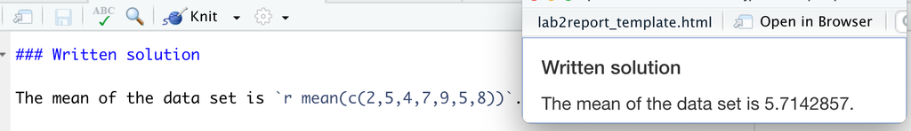

Or, if I define a value by name in a code chunk, say

```r
xbar = mean(c(2,5,4,7,9,5,8))
```

I can include this value in a written solution as follows:

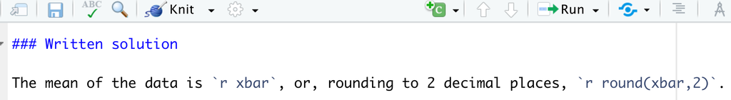

**R tip**: The `round()` function rounds results for us. For instance, `round(22/7,3)` rounds the fraction 22/7 to three decimal places (3.143).

# Q1 - A box full of marbles

In a box full of orange and blue marbles we wonder what proportion of them are blue.

If we are unable or unwilling to count the entire population of marbles, we might study a sample, a simple random sample of size 35, perhaps.

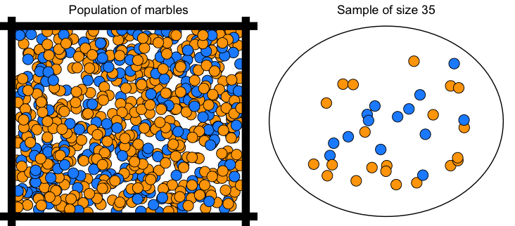

In the image above, 14 of the 35 marbles in the sample are blue, giving us a sample proportion of blue marbles equal to
$$\hat{p}=\frac{14}{35}=.40.$$

How close is this point estimate $\hat{p}$ likely to be to the true proportion $p$ of blue marbles in the jar? The goal of this exercise is to answer this question via simulation and the central limit theorem for proportions.

When you ran the code chunk in the Lab 2 template file instructions, which included the code below, you defined the data set `marbles` consisting of 2400 orange and blue marbles in a box.

```r
marbles <- rep(c("blue","orange"),c(900,1500))
```

1. The following code draws a simple random sample of 50 marbles from the box of marbles, and then counts how many of them are blue.

```r
sum(sample(marbles,50)=="blue")
```

Copy and paste this code in the console prompt, (or create a new script file as a work space for this lab and paste the code there). Then run this code to create your very own random sample of size 50 marbles from the box. In the [Q1a] Written Solution space, record the number of blue marbles in your sample as well as the proportion of blue marbles in your sample.

2. Run that code again to generate a new sample of 50 marbles, and record the number and proportion of blue marbles in your second sample as your written solution to [Q1b]. Are the two sample proportions you’ve generated different? Is that surprising?
3. The following code repeats the process of sampling 50 marbles and recording the sample proportion of blue marbles many, many times. 10,000 times, in fact. Copy and paste this code into your lab [Q1c] code chunk to generate your own 10,000 repetitions of the sampling process. What was the highest sample proportion of blue marbles of these 10,000 repetitions? What was the lowest? Record these extreme values in your written solution to this part.

```r
set.seed(240)
size = 50 # sample size is each trial
reps = 10000 # total number of repetitions of the sampling process
s_prop_50 <- c() # the vector that stores all the sample proportions in samples of size 50
for (i in 1:reps){
  trial_samp <- sample(marbles,size)
  prop=sum(trial_samp=="blue")/size
  s_prop_50[i]=prop
}
```

4. Make a well-labelled histogram of the 10,000 sample proportions working with `hist(s_prop_50, breaks=20)`. This histogram is a representation of the sampling distribution for $\hat{p}$. Does it look bell-shaped? Describe its center and spread by finding the mean and standard deviation of the distribution.
5. What proportion of your 10,000 sample proportions generated from samples of size 50 (and stored in `s_prop_50`) is between 0.30 and 0.45? We can find the total number of trials that produced a sample proportion in this range using this code:

   `sum((s_prop_50 >=.30)&(s_prop_50<=0.45))`.
6. Now, instead of sampling 50 marbles each turn, sample 100 marbles each turn, by using the code below. Make a well-labelled histogram of the 10,000 sample proportions stored in samp_prop_100, and compare this histogram with the histogram from (d). Pay attention to center and spread.

```r
size=100 # how large our sample size is for each trial
reps=10000 # total number of repetitions of the sampling process
s_prop_100 <- c() # the vector we build to story all the sample proportions in samples of size 100
for (i in 1:reps){
  trial_samp <- sample(marbles,size)
  s_prop=sum(trial_samp=="blue")/size
  s_prop_100[i]=s_prop
}

hist(s_prop_100,breaks=20,main="Give me a title please!",xlab="x-axis label!")
mean(s_prop_100)
sd(s_prop_100)
```

7. What proportion of the 10,000 sample proportions generated from samples of size 100 (and stored in `s_prop_100`) is between 0.30 and 0.45? How does this compare to your answer in (e).

# Q2 - The CLT for Proportions

Recall the **Central Limit Theorem** for proportions says that if certain conditions are met, sample proportions will be nearly normally distributed with mean equal to the population proportion, $p$, and standard error equal to $\text{SE}=\sqrt{\frac{p~(1-p)}{n}}$. So,
$$\hat{p} \sim N \left(p,\sqrt{\frac{p~(1-p)}{n}} \right)$$

1. The true proportion of blue marbles in the box is
   $$p = \frac{900}{2400} = .375.$$
   Check whether the following three conditions of the CLT for $\hat{p}$ are met if we draw a sample of size $n = 50$.
   - Is $np \geq 10$?
   - Is $n(1-p) \geq 10$?
   - Recall, the box has 2400 marbles. Is $n$ less than 10% of the population?
2. According to the CLT for proportions, what is the mean and what is the standard deviation of the sampling distribution for $\hat{p}$ when the sample size is $n = 50$?
3. Compare the mean and standard deviation of your 10,000 sample proportions from [Q1c] with the values of the mean and standard deviation predicted by the central limit theorem. Are they close?
4. Repeat parts (b-c) for the sampling distribution for $\hat{p}$ from [Q1f], when we took samples of size $n = 100$.

# Q3 Bedtime for Linfield Students

You overhear a friend say, “I bet over half of all Linfield students go to bed around midnight or later.” For the sake of this exercise, let’s treat the start of term class survey as a simple random sample of all Linfield students. When you ran the code chunk in the Lab 2 template file instructions you imported the survey results in a data frame called `survey`.

```r
survey <- read.csv("https://mphitchman.com/stats/data/survey_cleaned_F21.csv")
```

1. Use the `table()` function to help determine the sample proportion of students who indicate a bedtime that is *around midnight or later*.
2. Based on this sample, determine a 95% confidence interval for $p$, the proportion of all Linfield students who indicate a bedtime that is midnight or later. Show your work in a code chunk or two. Here’s one approach.

Recall, the formula for a 95% confidence interval for $p$ is
$$\hat{p} \pm 1.96*\sqrt{\frac{\hat{p}(1-\hat{p})}{n}}.$$

```r
phat = .1    # input correct sample proportion
n = 5      #input correct sample size
zstar = qnorm(.975) # critical z-score for 95% confidence - adjust for a different level
SE = sqrt(phat*(1-phat)/n) # this calculates standard error
MOE = zstar*SE # margin of error!
```

Then the lower and upper bounds for your interval are found as follows, and we can ask RStudio to print out the result as a sentence!

```r
lower_bound = phat - MOE
upper_bound = phat + MOE
print(paste("The 95% confidence interval for p is",round(lower_bound,3),"to",round(upper_bound,3)))
```

3. Based on this interval, do we have evidence to reject our friend’s claim that over half of all Linfield students go to bed around midnight or later? Explain.

# Q4 Eye color

According to Google (“us population eye color”), about 45% of Americans have brown eyes.

1. Looking again at the class survey data, and thinking of this sample as a simple random sample of all Linfield students, determine a 95% confidence interval for the true proportion of Linfield students having brown eyes. Show your work in the [Q4a] code chunk.
2. Based on your confidence interval in (a) do you have reason to believe that the percentage of Linfield students with brown eyes is different than 45%? Explain.